# WS3

SDS348

## Visualization II

```r
library(ggplot2) #the msleep dataset is part of the ggplot2 package

head(msleep)
```

```
## # A tibble: 6 x 11
##   name  genus vore  order conservation sleep_total sleep_rem sleep_cycle awake
##   <chr> <chr> <chr> <chr> <chr>              <dbl>     <dbl>       <dbl> <dbl>
## 1 Chee~ Acin~ carni Carn~ lc                  12.1      NA        NA      11.9
## 2 Owl ~ Aotus omni  Prim~ <NA>                17         1.8      NA       7
## 3 Moun~ Aplo~ herbi Rode~ nt                  14.4       2.4      NA       9.6
## 4 Grea~ Blar~ omni  Sori~ lc                  14.9       2.3       0.133   9.1
## 5 Cow   Bos   herbi Arti~ domesticated         4         0.7       0.667  20
## 6 Thre~ Brad~ herbi Pilo~ <NA>                14.4       2.2       0.767   9.6
## # ... with 2 more variables: brainwt <dbl>, bodywt <dbl>
```

```r
str(msleep)
```

```
## tibble [83 x 11] (S3: tbl_df/tbl/data.frame)
##  $ name        : chr [1:83] "Cheetah" "Owl monkey" "Mountain beaver" "Greater short-tailed shrew" ...
##  $ genus       : chr [1:83] "Acinonyx" "Aotus" "Aplodontia" "Blarina" ...
##  $ vore        : chr [1:83] "carni" "omni" "herbi" "omni" ...
##  $ order       : chr [1:83] "Carnivora" "Primates" "Rodentia" "Soricomorpha" ...
##  $ conservation: chr [1:83] "lc" NA "nt" "lc" ...
##  $ sleep_total : num [1:83] 12.1 17 14.4 14.9 4 14.4 8.7 7 10.1 3 ...
##  $ sleep_rem   : num [1:83] NA 1.8 2.4 2.3 0.7 2.2 1.4 NA 2.9 NA ...
##  $ sleep_cycle : num [1:83] NA NA NA 0.133 0.667 ...
##  $ awake       : num [1:83] 11.9 7 9.6 9.1 20 9.6 15.3 17 13.9 21 ...
##  $ brainwt     : num [1:83] NA 0.0155 NA 0.00029 0.423 NA NA NA 0.07 0.0982 ...
##  $ bodywt      : num [1:83] 50 0.48 1.35 0.019 600 ...
```

```r
#notice it displays differently... let's make it a dataframe for now

msleep<-as.data.frame(msleep)
```

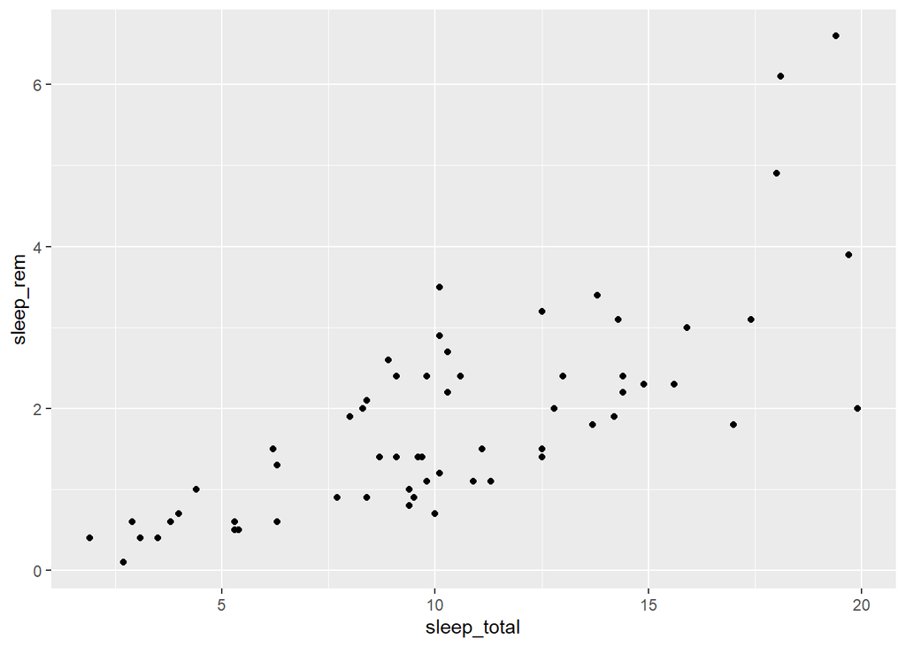

```r
ggplot(msleep, aes(sleep_total,sleep_rem)) + geom_point()
```

Add a smoothing function to the previous plot with geom_smooth()

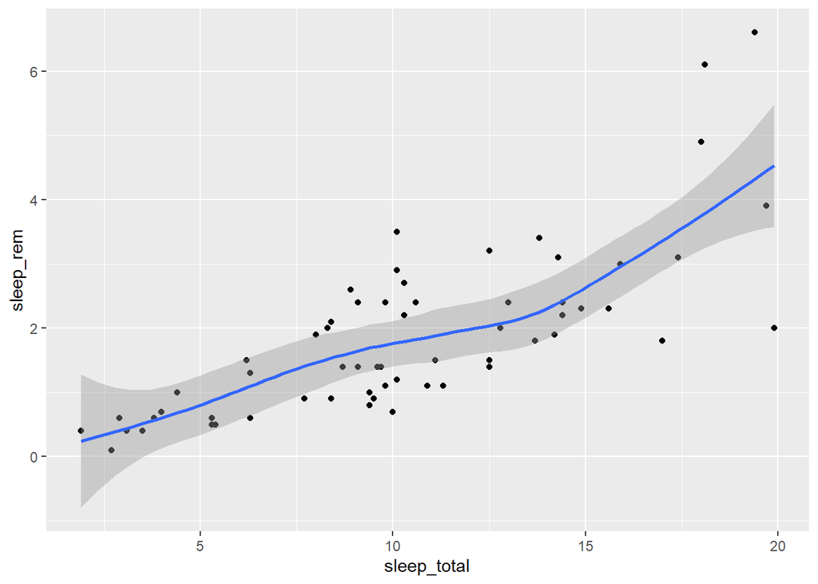

```r
ggplot(msleep, aes(sleep_total,sleep_rem)) + geom_point() + geom_smooth()
```

Make it a linear regression line instead of loess

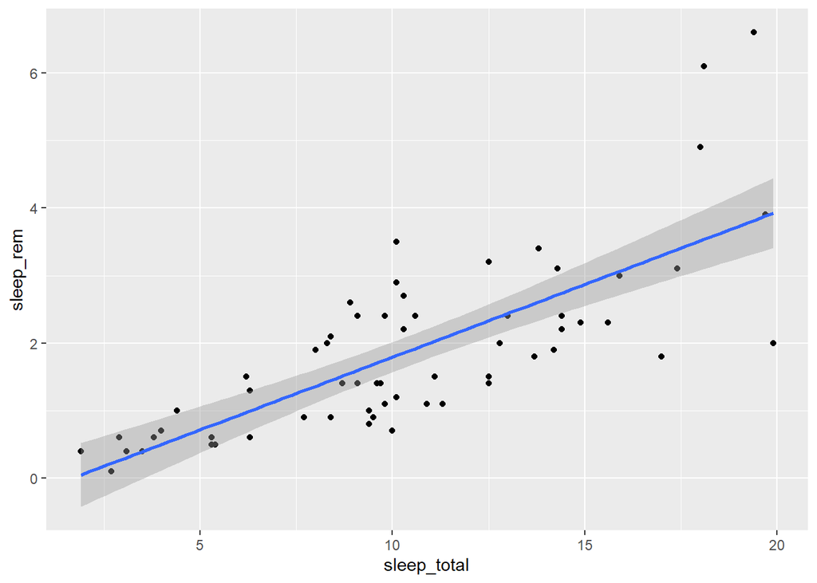

```r
ggplot(msleep, aes(sleep_total,sleep_rem)) + geom_point() + geom_smooth(method="lm")
```

Go back to your original scatterplot. Now, in aes(), map vore onto color and bodywt onto size

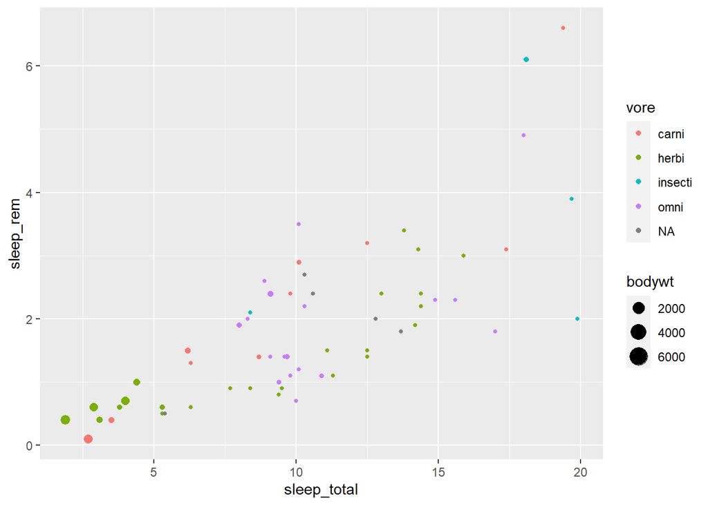

```r
ggplot(msleep, aes(sleep_total,sleep_rem,size=bodywt, color=vore)) + geom_point()
```

Create a new dataset excluding rows where vore is NA

```r
msleep1<-msleep[!is.na(msleep$vore),] #remove rows where vore==NA
ggplot(msleep1, aes(vore))+geom_bar(stat="count")
```

[output not shown]

Can leave off stat=“count” (it’s the default behavior)

```r
ggplot(msleep1, aes(x = vore))+geom_bar() #leave off stat="count"
```

[output not shown]

Create a new variable with `ifelse()` function

```r
#create a new variable with ifelse(test, yes, no)

msleep1$size <- ifelse(msleep1$bodywt < median(msleep1$bodywt), "Small", "Large")

str(msleep1)
```

```
## 'data.frame':    76 obs. of  12 variables:
##  $ name        : chr  "Cheetah" "Owl monkey" "Mountain beaver" "Greater short-tailed shrew" ...
##  $ genus       : chr  "Acinonyx" "Aotus" "Aplodontia" "Blarina" ...
##  $ vore        : chr  "carni" "omni" "herbi" "omni" ...
##  $ order       : chr  "Carnivora" "Primates" "Rodentia" "Soricomorpha" ...
##  $ conservation: chr  "lc" NA "nt" "lc" ...
##  $ sleep_total : num  12.1 17 14.4 14.9 4 14.4 8.7 10.1 3 5.3 ...
##  $ sleep_rem   : num  NA 1.8 2.4 2.3 0.7 2.2 1.4 2.9 NA 0.6 ...
##  $ sleep_cycle : num  NA NA NA 0.133 0.667 ...
##  $ awake       : num  11.9 7 9.6 9.1 20 9.6 15.3 13.9 21 18.7 ...
##  $ brainwt     : num  NA 0.0155 NA 0.00029 0.423 NA NA 0.07 0.0982 0.115 ...
##  $ bodywt      : num  50 0.48 1.35 0.019 600 ...
##  $ size        : chr  "Large" "Small" "Small" "Small" ...
```

Map new size variable onto fill=

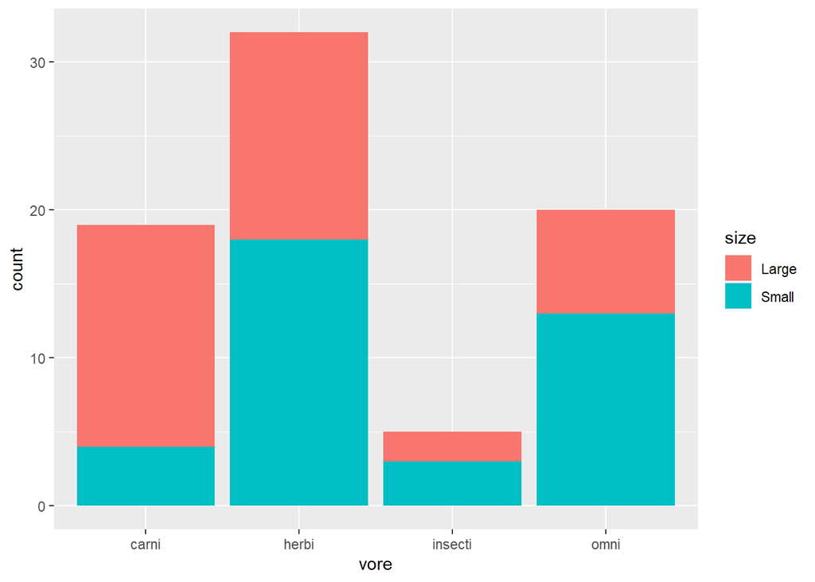

```r
ggplot(msleep1, aes(x = vore, fill=size)) + geom_bar()
```

Flip the factor levels manually to change ordering/coloring

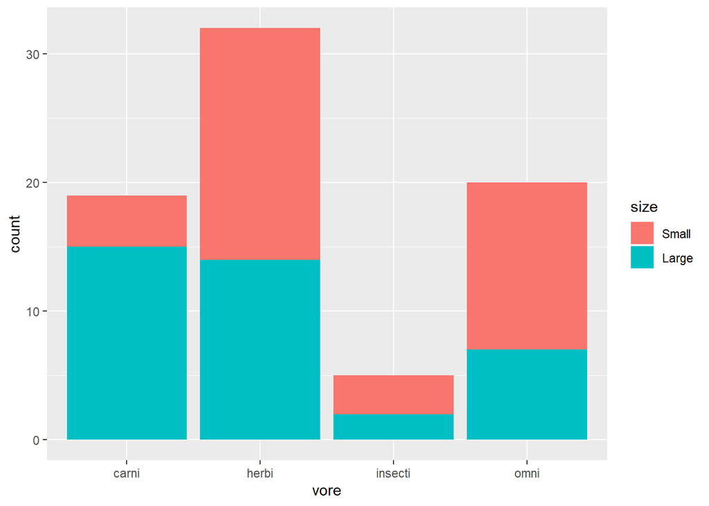

```r
msleep1$size <- factor(msleep1$size, levels = c("Small","Large"))

ggplot(msleep1, aes(x = vore, fill=size)) + geom_bar()
```

Put bars side-by-side with position=“dodge”

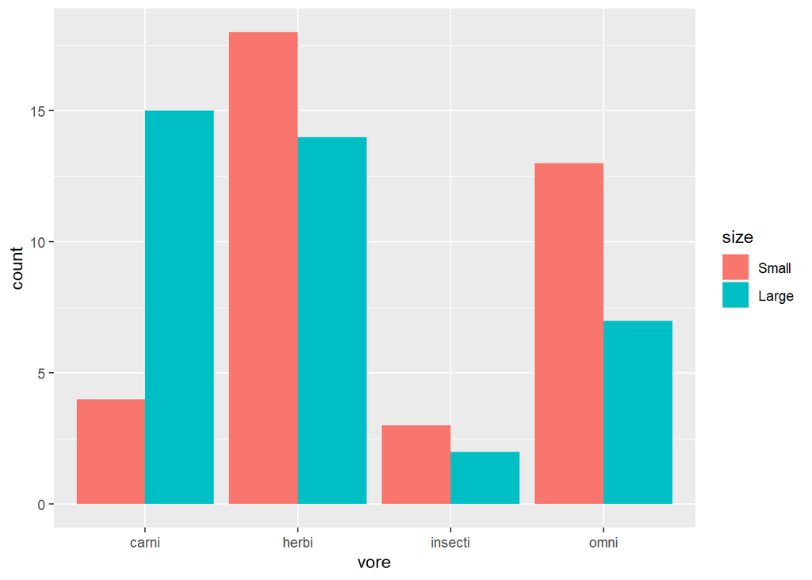

```r
ggplot(msleep1, aes(x = vore, fill=size))+
  geom_bar(position="dodge")
```

Make bars proportions of size for each vore category with position=“fill”

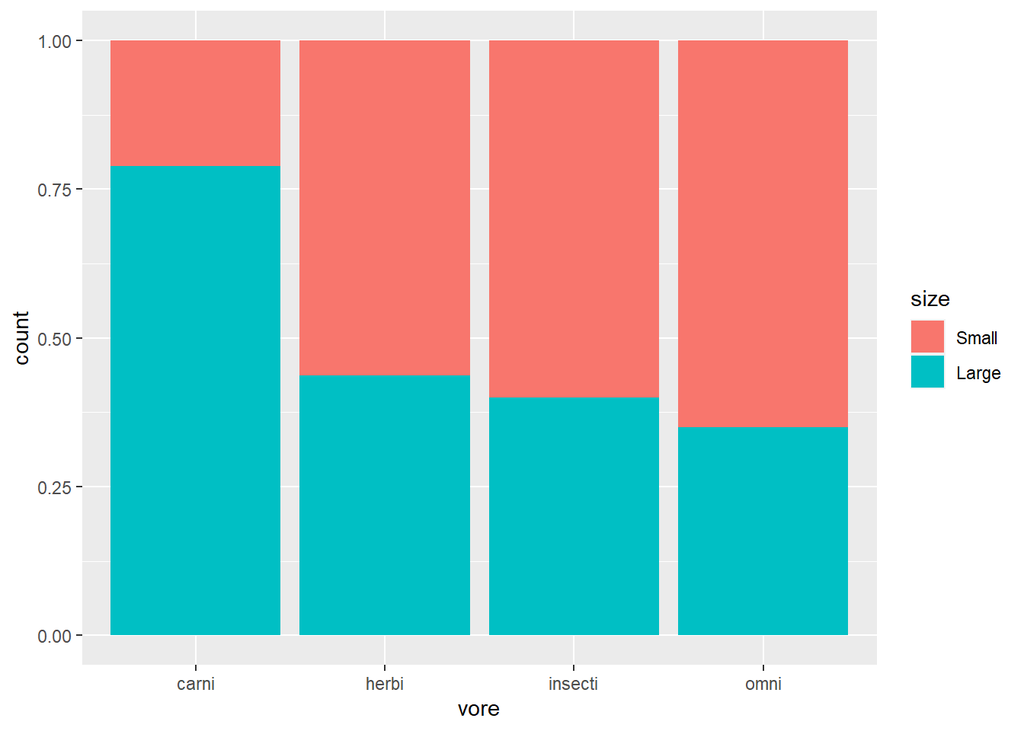

```r
ggplot(msleep1, aes(x = vore, fill=size))+
  geom_bar(position="fill")
```

Make bars proportions of vore category for each size

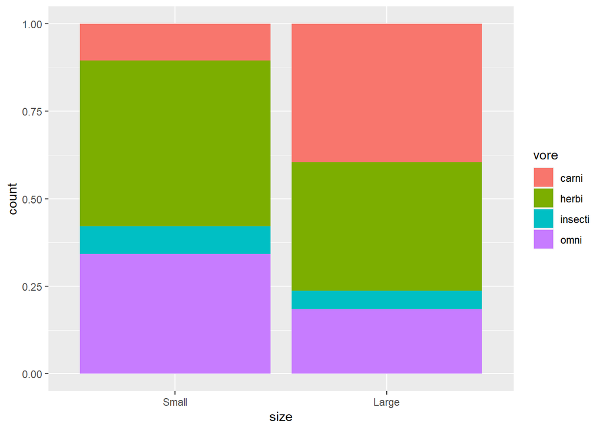

```r
ggplot(msleep1, aes(x = size, fill=vore))+
  geom_bar(position='fill')
```

These are equivalet, but I like the first better

```r
ggplot(msleep1, aes(vore))+
  geom_bar(stat="count")
```

[output not shown]

```r
ggplot(msleep1, aes(vore))+
  stat_count(geom="bar")
```

[output not shown]

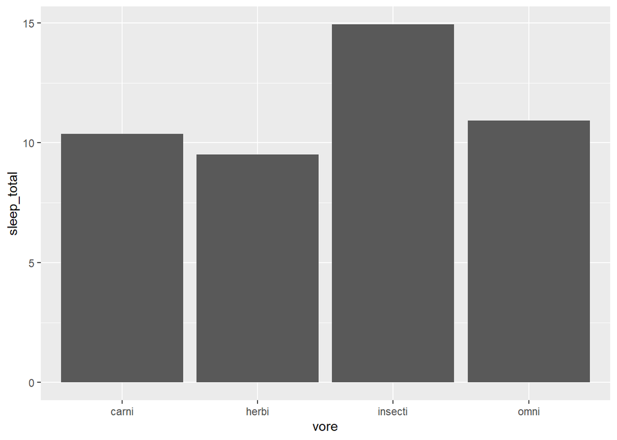

```r
ggplot(msleep1, aes(x = vore))+
  geom_bar(aes(y=sleep_total), stat="summary", fun=mean)
```

Add standard error ($\frac{s}{\sqrt{n}}$) bars

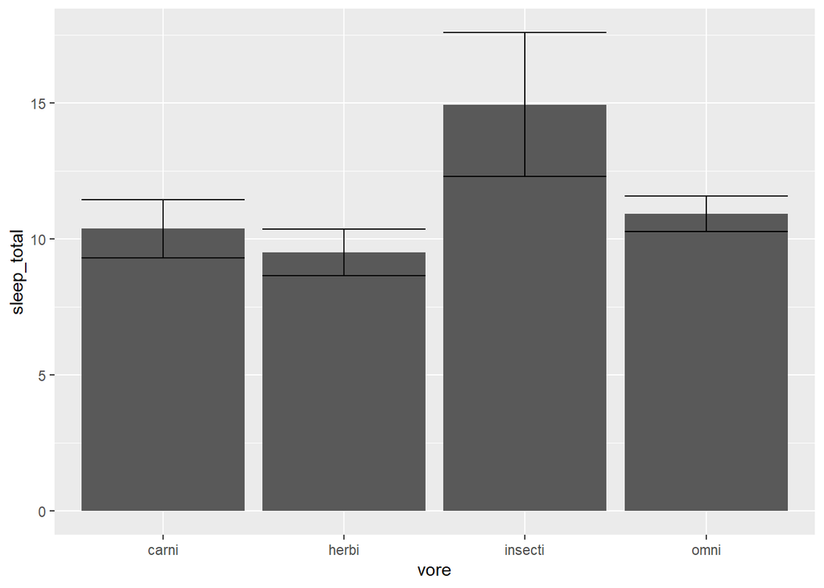

```r
ggplot(msleep1, aes(x = vore, y = sleep_total))+
  geom_bar(stat="summary",fun=mean)+
  geom_errorbar(stat="summary", fun.data=mean_se)
```

[output not shown]

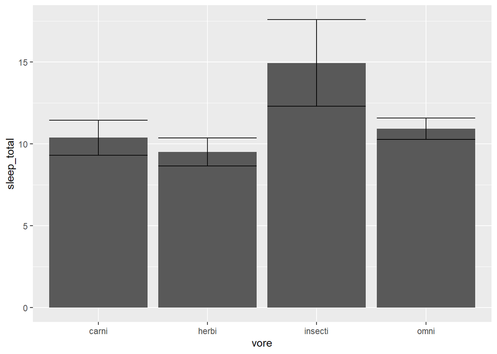

```r
#same as

ggplot(msleep1, aes(x = vore, y = sleep_total))+
  geom_bar(stat="summary")+
  geom_errorbar(stat="summary")
```

95% CI instead

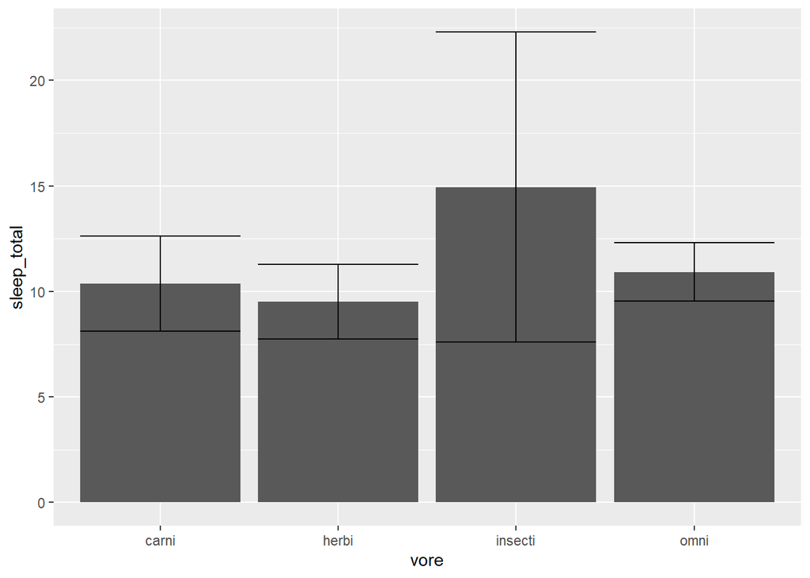

```r
ggplot(msleep1, aes(x = vore, y = sleep_total))+
  geom_bar(stat="summary",fun=mean)+
  geom_errorbar(stat="summary", fun.data=mean_cl_normal)
```

Standard error bars on a grouped bar plot (position=“dodge”)

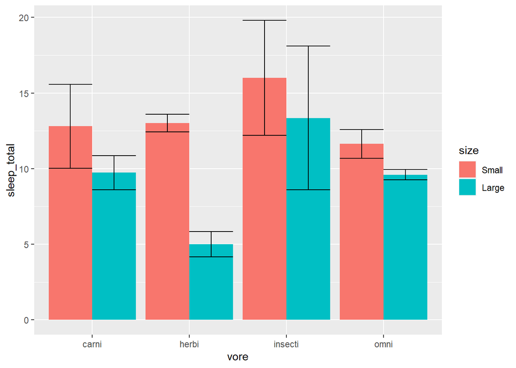

```r
ggplot(msleep1, aes(x = vore, y = sleep_total, fill=size))+
  geom_bar(stat="summary", fun=mean, position="dodge")+
  geom_errorbar(stat="summary", fun.data=mean_se, position="dodge")
```

OK, let’s make a bigger bar plot

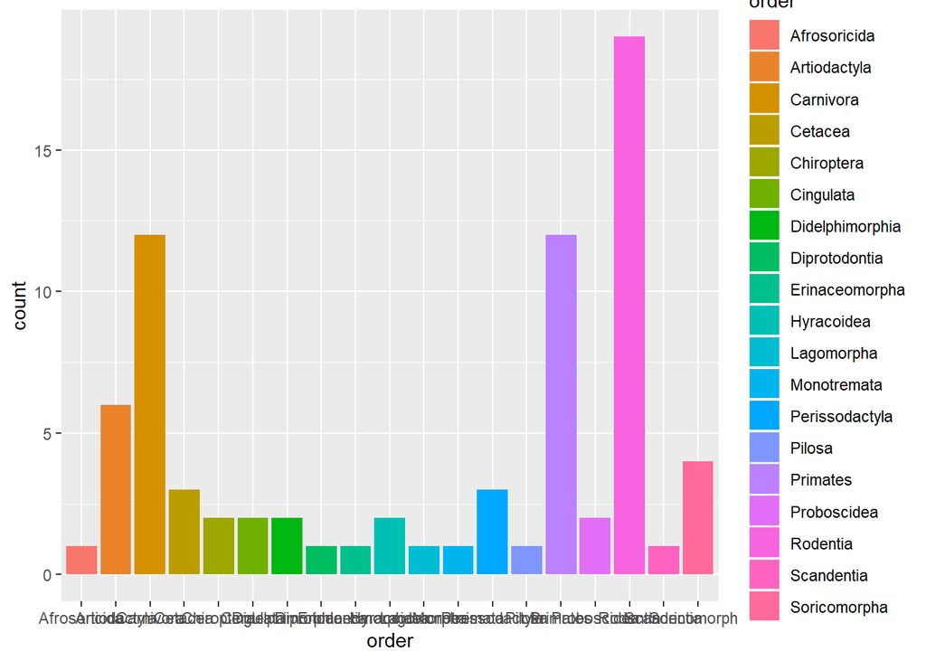

```r
ggplot(msleep1, aes(order))+
  geom_bar(aes(fill=order))
```

Yuck, too crowded in the x-axis! Let’s rotate them and whack the legend

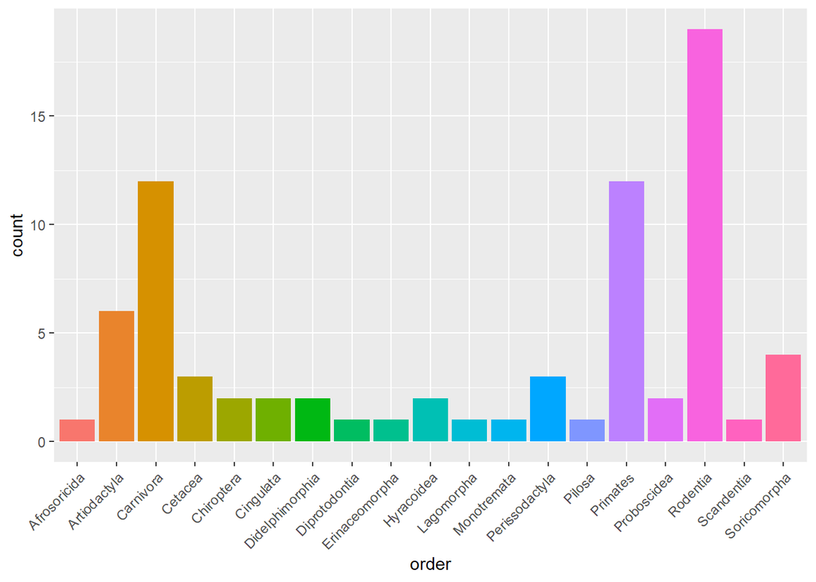

```r
ggplot(msleep1, aes(order)) +
  geom_bar(aes(fill=order)) +
  theme(axis.text.x = element_text(angle=45, hjust=1),
        legend.position="none")
```

Alternatively, we could rotate this sucker with coord_flip()

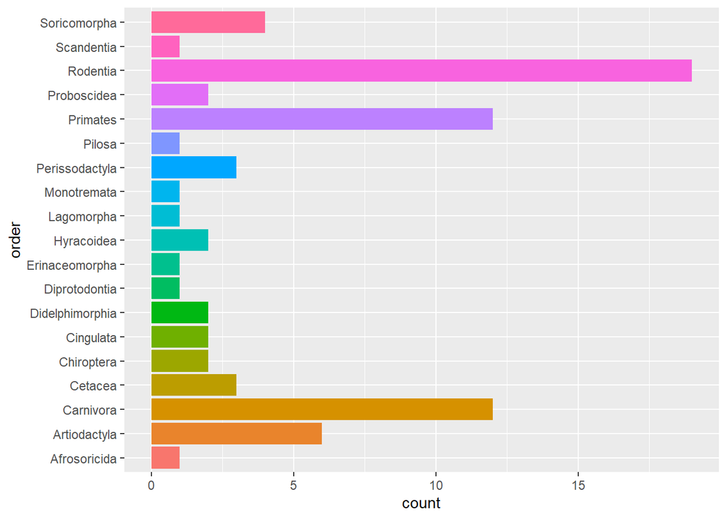

```r
ggplot(msleep1, aes(order))+
  geom_bar(aes(fill=order))+
  coord_flip()+
  theme(legend.position="none")
```

Average bodyweight for each order?

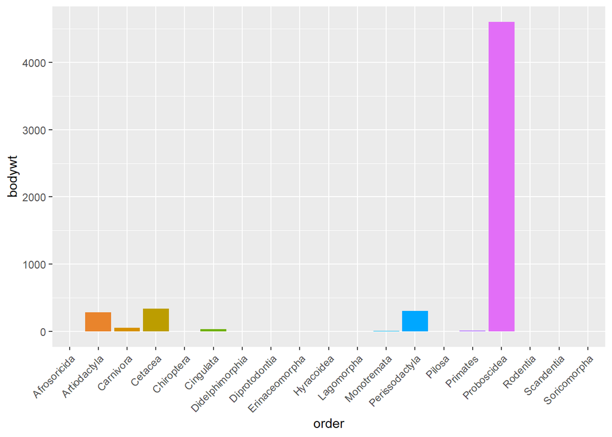

```r
ggplot(msleep1, aes(order))+
  stat_summary(aes(y = bodywt, fill = order),geom = "bar", fun=mean) +
  theme(axis.text.x  = element_text(angle=45, hjust = 1), legend.position="none")
```

Proportion of vore for each size again

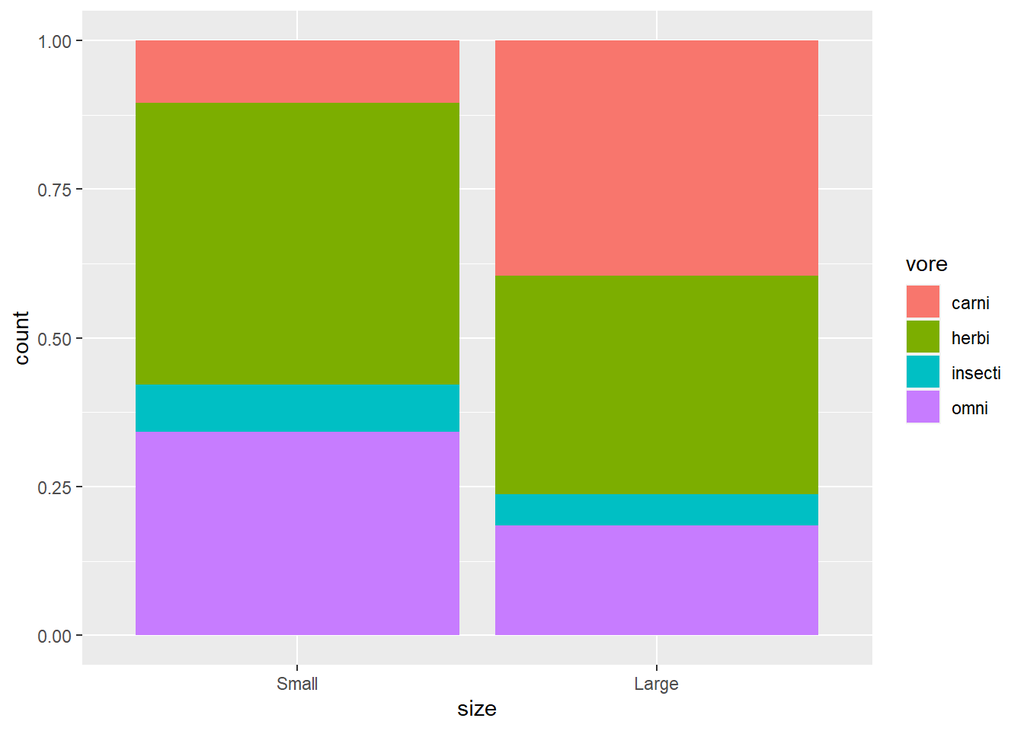

```r
ggplot(msleep1, aes(x = size, fill=vore))+
  geom_bar(position='fill')
```

More tick marks? Set breaks argument manually

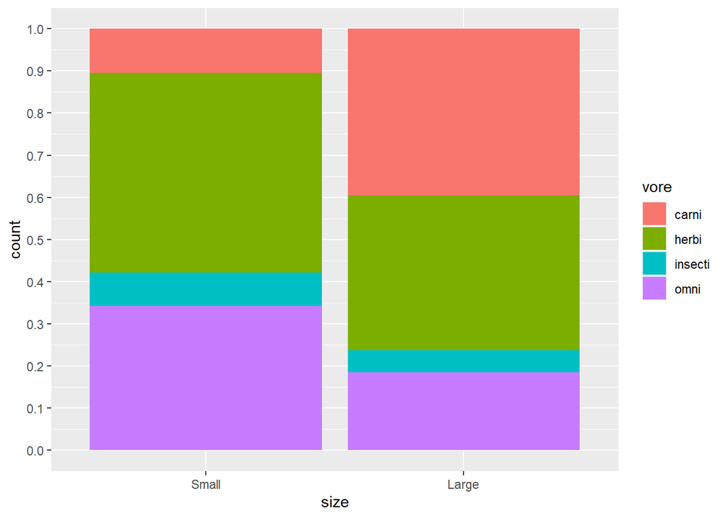

```r
ggplot(msleep1, aes(x = size, fill=vore))+
  geom_bar(position='fill')+scale_y_continuous(breaks = seq(0,1,.1))
```

Label them as percentages rather than decimals

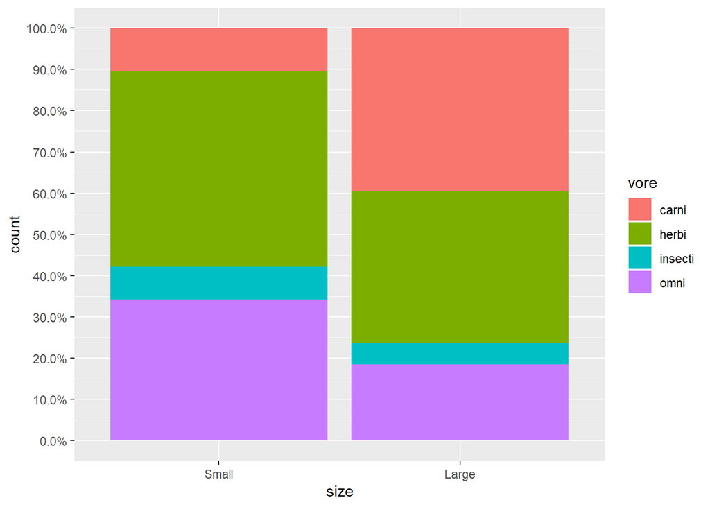

```r
ggplot(msleep1, aes(x = size, fill=vore))+
  geom_bar(position='fill')+scale_y_continuous(breaks=seq(0,1,.1), labels=scales::percent)
```

Label them nonsensically as dollar amounts

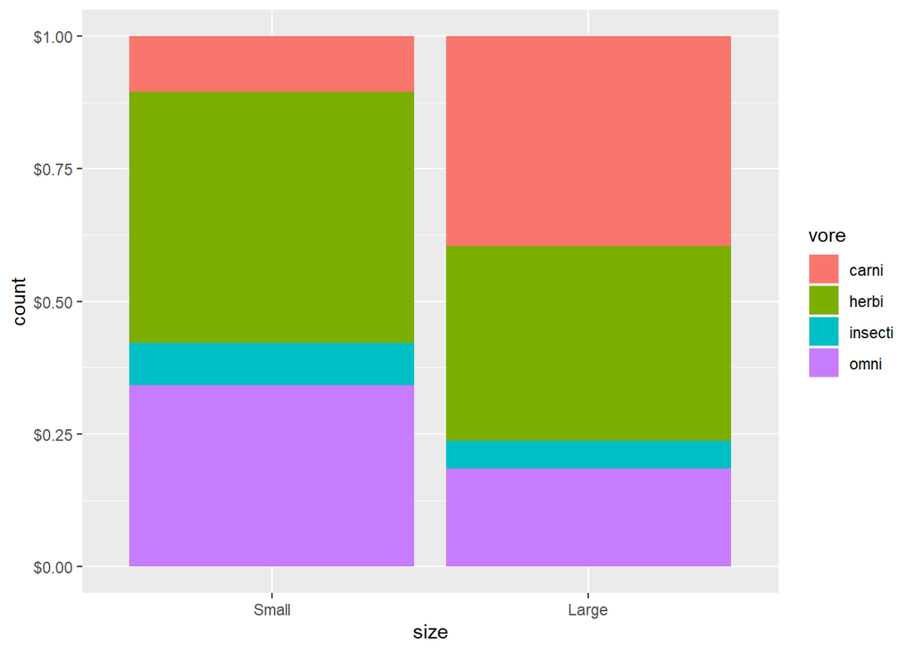

```r
ggplot(msleep1, aes(x = size, fill=vore))+
  geom_bar(position='fill')+scale_y_continuous(labels=scales::dollar)
```

Let’s look at a plot of brain weight (y-axis) by body weight (x-axis)

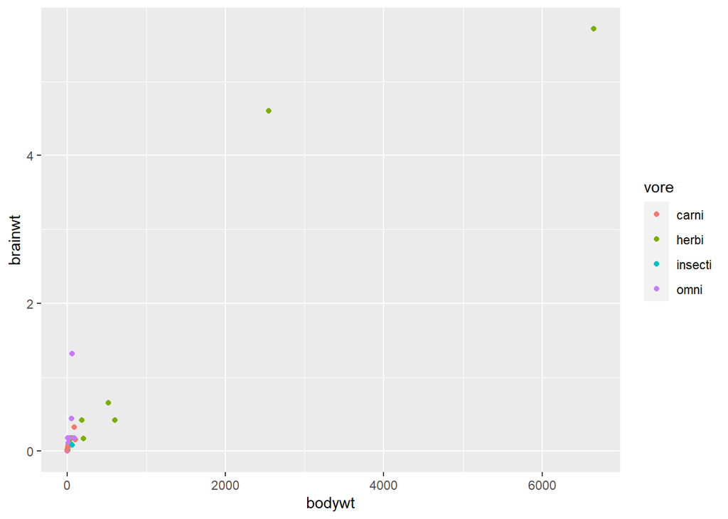

```r
ggplot(msleep1, aes(bodywt, brainwt, color=vore))+geom_point() #note the warning! it is dropping missing values!
```

Who are the big daddys?

```r
msleep1[msleep1$bodywt>1000,]
```

```
##                name     genus  vore       order conservation sleep_total
## 21   Asian elephant   Elephas herbi Proboscidea           en         3.9
## 36 African elephant Loxodonta herbi Proboscidea           vu         3.3
##    sleep_rem sleep_cycle awake brainwt bodywt  size
## 21        NA          NA  20.1   4.603   2547 Large
## 36        NA          NA  20.7   5.712   6654 Large
```

We can limit what is shown in our plot by manually setting x/y limits

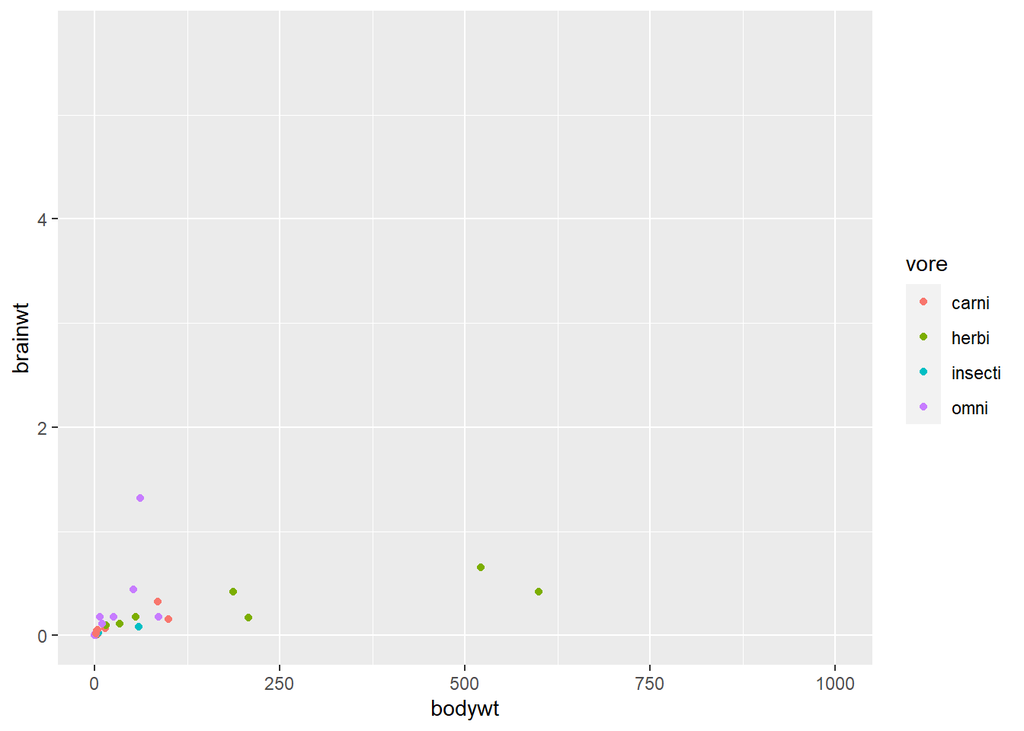

```r
ggplot(msleep1, aes(bodywt, brainwt, color=vore))+geom_point()+
  scale_x_continuous(lim=c(0,1000))
```

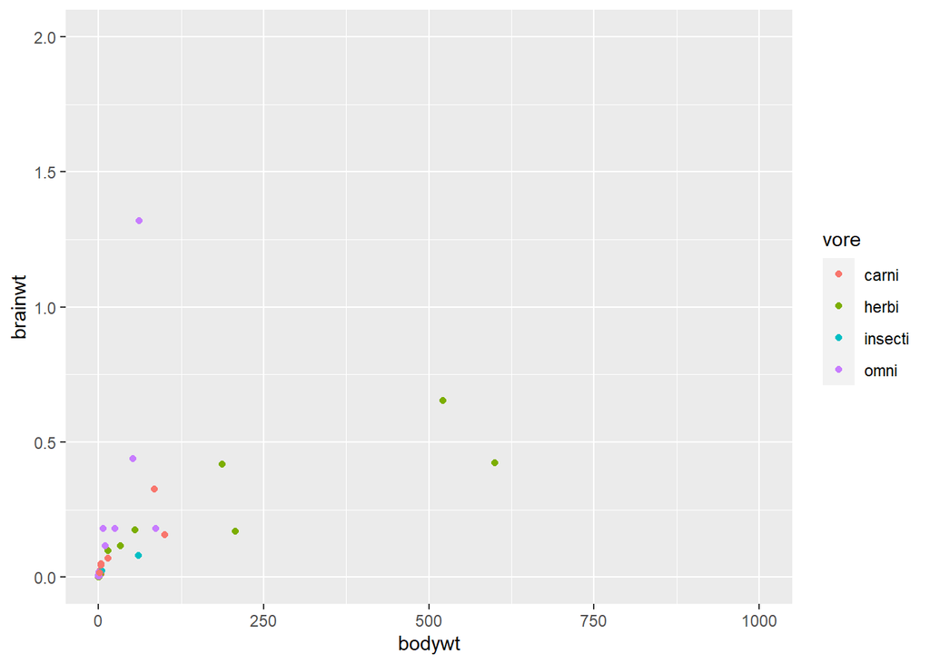

```r
ggplot(msleep1, aes(bodywt, brainwt, color=vore))+geom_point()+
  scale_x_continuous(lim=c(0,1000))+
  scale_y_continuous(lim=c(0,2))
```

Same thing, but sometimes quicker

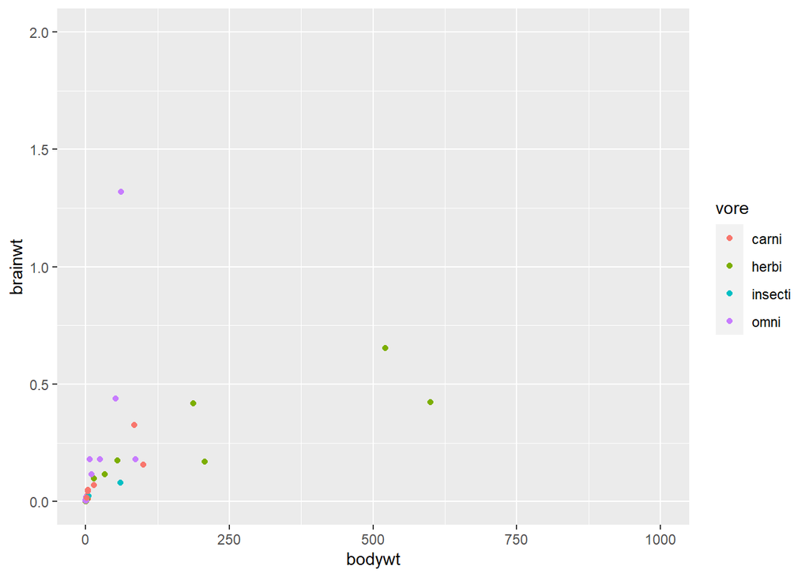

```r
ggplot(msleep1, aes(bodywt, brainwt, color=vore))+geom_point()+
  xlim(0,1000)+ylim(0,2)
```

Let’s make the tick marks increase geometrically rather than linearly

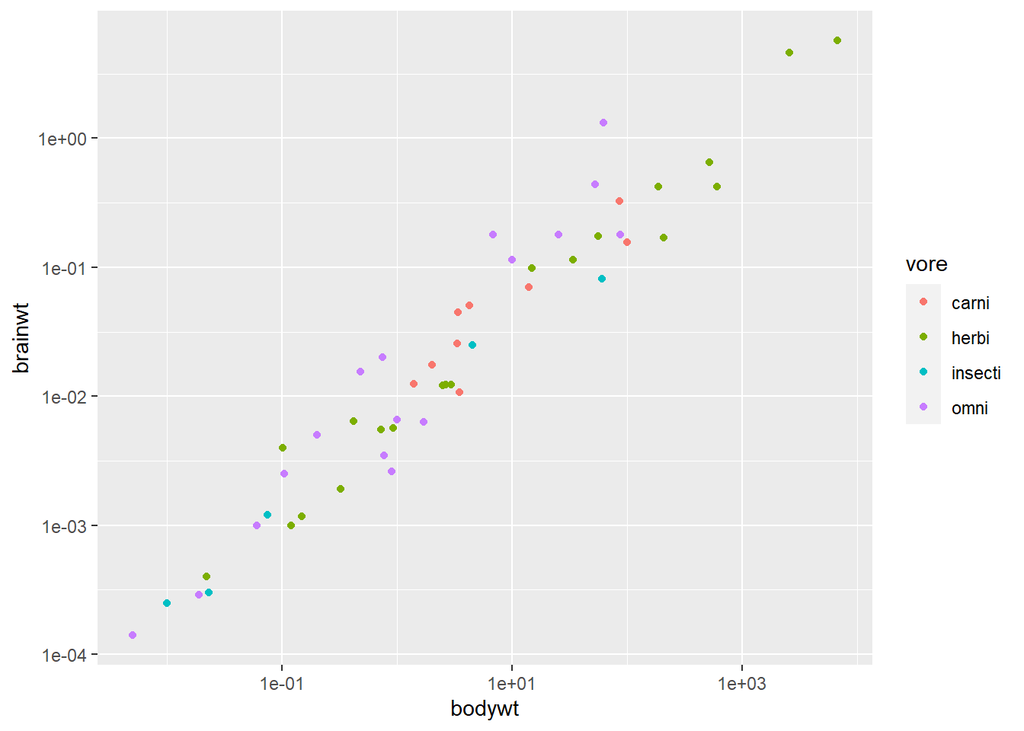

```r
ggplot(msleep1, aes(bodywt, brainwt, color=vore))+geom_point()+
  scale_x_log10()+scale_y_log10()
```

```r
#interesting!
```

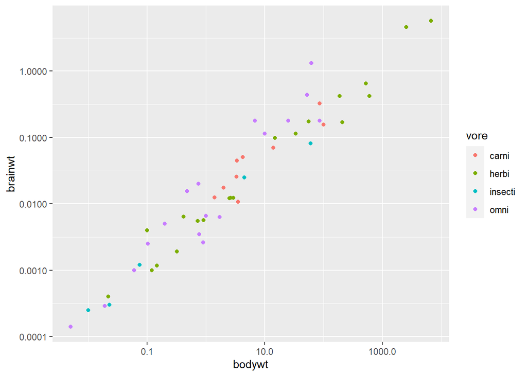

```r
## increase threshold for scientific notation
options(scipen = 999)

ggplot(msleep1, aes(bodywt, brainwt, color=vore))+geom_point()+
  scale_x_log10()+scale_y_log10()
```

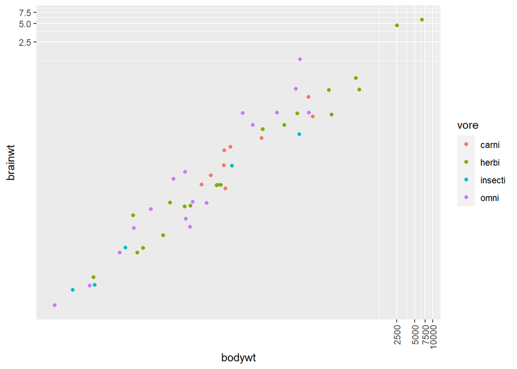

```r
ggplot(msleep1, aes(bodywt, brainwt, color=vore))+geom_point()+
  coord_trans(x="log10",y="log10")+scale_x_continuous(breaks=seq(0,10000,2500))+
  theme(axis.text.x=element_text(angle=90, vjust=.5, hjust=1))
```

Change fill colors!

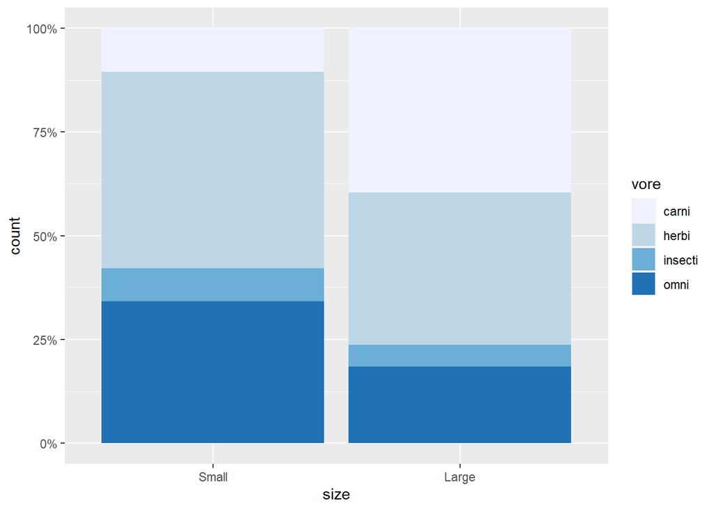

```r
ggplot(msleep1, aes(x = size, fill=vore))+
  geom_bar(position='fill')+scale_y_continuous(labels=scales::percent)+
  scale_fill_brewer()
```